# Aspectos clave para el médico residente al planear y ejecutar su tesis

LII Curso Anual de Actualización en Anestesiología y Medicina Perioperatoria

Javier Mancilla Galindo

javimangal@gmail.com

Institute for Risk Assessment Sciences, Utrecht University, Utrecht, Países Bajos

21 de agosto de 2026

# Sobre mí

## Sobre mí

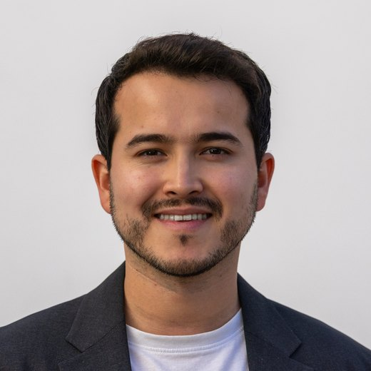

[Perfil institucional](https://research-portal.uu.nl/en/persons/javier-mancilla-galindo/)

[figure not shown]

- Médico Cirujano, Facultad de Medicina UNAM.
- Maestro en Epidemiología, Universidad de Utrecht, Países Bajos.
- Investigador en el Institute for Risk Assessment Sciences, Universidad de Utrecht.
- **Experto en metodología** del Consenso Mexicano de Ventilación Mecánica Perioperatoria del COMEXANE.
- Supervisor de 3 tesis de maestría y colaborador en numerosas tesis de especialidad médica.

## Publicaciones por diseño de estudio

[interactive chart not shown]

Además: 6 resúmenes en congresos, 6 conjuntos de datos abiertos, 5 revisiones narrativas, 7 cartas y comentarios, 5 capítulos y material docente.

## Contenidos

- **Introducción:** ¿debe ser obligatoria la tesis?
- **Planeación:** pregunta de investigación y diseño de estudio
- **Ejecución:** Análisis estadístico y reproducibilidad
- **Inteligencia artificial:** qué puede y qué no puede hacer por ti

# Introducción

## Debate: ¿debe ser obligatoria la tesis?

Carta al Editor

[La tesis no debería ser obligatoria en las residencias médicas](https://doi.org/10.22201/fm.20075057e.2026.59.26804)

Giordano Pérez Gaxiola

*Investigación en Educación Médica*  
2026;15(59):168-169

Editorial

[Investigar para aprender o para cumplir: repensando la tesis en las residencias médicas](https://doi.org/10.22201/fm.20075057e.2026.59.26808)

Melchor Sánchez Mendiola

*Investigación en Educación Médica*  
2026;15(59):6-9

## Contraste de argumentos

En contra de la obligatoriedad

- No influye en las competencias clínicas
- Carga asistencial y administrativa: casi nadie tiene tiempo protegido
- Pocos tutores: quien consigue uno comprometido tiene ventaja
- Empuja a estudios retrospectivos con expedientes incompletos, que no se publican
- En el peor caso: plagio, datos inventados, autorías compradas, uso irresponsable de IA

Matiz del editor

- El problema no es investigar: es exigirlo sin infraestructura
- La NOM-001-SSA-2023 pide “cuando menos un trabajo de investigación”, no una tesis
- La ACGME habla de *scholarship*, no de un producto único
- La productividad académica no mejora por decreto
- Propuesta: “actividad académica supervisada, flexible y evaluable”

“El problema no es la investigación, sino la exigencia de investigación en condiciones no ideales.”<sup>2</sup>

Sánchez Mendiola M. Editorial. *Investigación en Educación Médica*. 2026;15(59):6-9

## Y mientras tanto, hay que entregar la tesis…

- El debate va para largo. La fecha de titulación, no…
- Buena parte de lo que se discute (tiempo protegido, tutores, comités ágiles) **no depende del residente**.
- Lo que sí depende: **elegir bien la pregunta**, **elegir un diseño de estudio adecuado y factible**, **organizar y cumplir con el cronograma de actividades** y **publicación**.
- No puedo abordar todos estos temas hoy; la platica se enfoca principalmente en los primeros dos.

## Recursos clave

- Mancilla Galindo y SMMCE: [Seminarios de Investigación Clínica](https://www.youtube.com/watch?v=8_IYfZ1gOa8&list=PLMx6l8_hnWLC2mhOS3Z7yYjMy3-px8RuX)
- International Anesthesia Research Society: [Tutoriales sobre métodos de investigación y bioestadística](https://journals.lww.com/anesthesia-analgesia/collections/188)
- Chest Journal: [Tutoriales de diseños de estudio y estadística](https://journal.chestnet.org/issue/S0012-3692%2820%29X0008-0) (incluyendo cálculo de tamaño de muestra)

# Planeación

## ¿Vale la pena esta pregunta? El marco FINER

Criterios FINER, propuestos por Cummings, Browner y Hulley en la primera edición de *Designing Clinical Research*<sup>3</sup>

| Criterio | Lo que hay que preguntarse |
| --- | --- |
| **F**actible | ¿Hay pacientes suficientes, tiempo, dinero y quien sepa analizarlo? ¿Cabe en la residencia? |
| **I**nteresante | ¿La respuesta le importa a alguien más que al comité de tesis? |
| **N**ovedosa | ¿Confirma, refuta o amplía lo ya publicado? Se contesta buscando, no suponiendo. |
| **É**tica | ¿La aprobaría un comité de ética e investigación tal como está escrita? |
| **R**elevante | ¿Cambia la práctica clínica, la política de salud o la investigación que viene después? |

## La pregunta PICO

- **P** - Población: ¿en quién? Edad, escenario, criterios de entrada.
- **I** - Intervención o exposición: ¿qué se hace o a qué está expuesto?
- **C** - Comparación: ¿frente a qué? Placebo, práctica habitual, no exposición.
- **O** - Desenlace (*outcome*): ¿qué se mide, cuándo y con qué instrumento?
- Fuente: https://www.cebm.ox.ac.uk/resources/ebm-tools/asking-focused-questions

## Un marco para cada tipo de pregunta

Ejemplos según Hosseini et al.<sup>5</sup>

| Tipo de estudio | Marco | Componentes |
| --- | --- | --- |
| Intervención / efectividad | PICO(T/S) | Población, Intervención, Comparador, Desenlace, (Tiempo / tipo de estudio) |
| Etiología, riesgo o causa | PEO | Población, Exposición o entorno, Desenlace |
| Incidencia o prevalencia | CoCoPop | Condición, Contexto, Población |
| Pruebas diagnósticas | PIRD | Población, Prueba índice, Prueba de referencia, Diagnóstico de interés |
| Pronóstico | PFO | Población, Factor pronóstico o modelo, Desenlace |
| Costo-efectividad | PICOC | Población, Intervención, Comparador, Desenlaces, Contexto |
| Metodológico | SDMO | Tipo de estudio, Tipo de datos, Métodos, Desenlace |
| Teoría o modelo | BeHEMoTh | Conducta, Contexto de salud, Exclusiones, Modelos o teorías |
| Psicometría | CPTM | Constructo, Población, Tipo de instrumento, Propiedades de medición |

## Marcos para preguntas cualitativas y de síntesis

Ejemplos según Hosseini et al.<sup>5</sup>

| Tipo de estudio | Marco | Componentes |
| --- | --- | --- |
| Cualitativo | PICo | Población, Fenómeno de interés, Contexto |
| Cualitativo | PPhTS | Participantes, Fenómeno central, Tiempo, Espacio |
| Cualitativo en salud pública | SPICE | Entorno, Perspectiva, Intervención, Comparación, Evaluación |
| Cualitativo o mixto | SPIDER | Muestra, Fenómeno de interés, Diseño, Evaluación, Tipo de investigación |
| Cualitativo organizacional | CIMO | Contexto, Intervención, Mecanismo, Desenlace |
| Políticas y gestión en salud | ECLIPSe | Expectativa, Grupo destinatario, Lugar, Impacto, Profesionales, Servicio |
| Revisión de alcance (Scoping Review) | PCC | Población, Concepto, Contexto |

## Elegir el diseño que la pregunta admite

- Distintos diseños de estudio se adaptan a una misma pregunta.
- La elección del diseño de estudio depende de factores como factibilidad, recursos, tiempo, etc.
- En muchos casos, no todos los diseños de estudio serán factibles en 2-3 años.

## Tipos de estudio

[figure not shown]

Adaptado del esquema de tipos de estudio del Centre for Evidence-Based Medicine (Oxford). Fuente: https://www.cebm.ox.ac.uk/resources/ebm-tools/study-designs

## Jerarquía de la evidencia

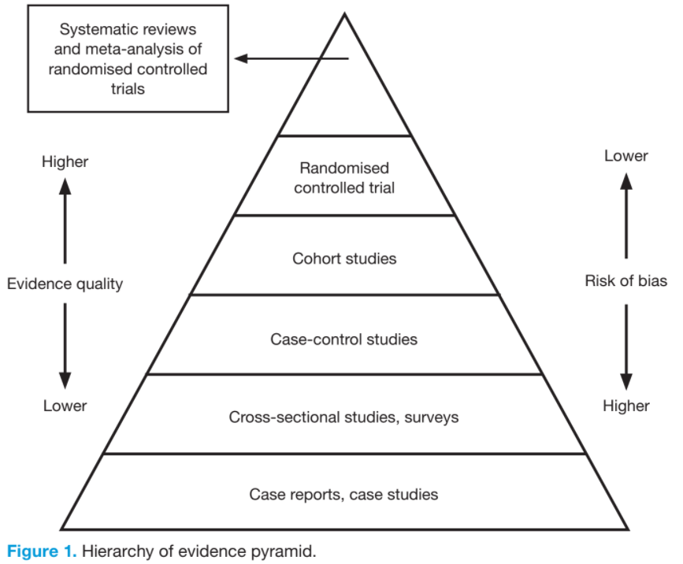

Aquilina et al.<sup>6</sup>

## Niveles de evidencia de Oxford

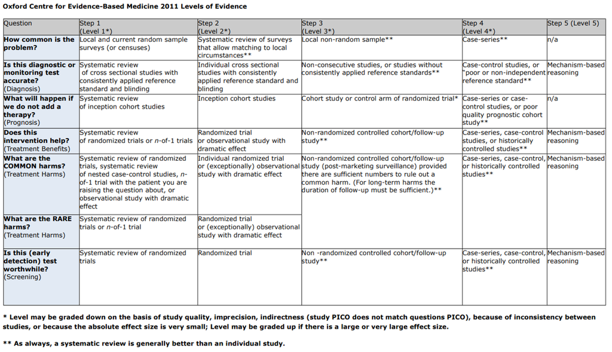

Oxford Centre for Evidence-Based Medicine, 2011<sup>7</sup>

## ¿Puede la IA elegir el diseño de estudio por ti?

> Quiero diseñar un estudio para mi tesis de residencia para saber cuál es la mejor estrategia ventilatoria para prevenir atelectasias postoperatorias. Considera que tengo pocos recursos y tiempo. ¿Cuál diseño de estudio debo elegir?

# Ejecución

## Recolección de datos

- **Diccionario de variables**: MUY IMPORTANTE
- Yo sigo las guías del [Open Science Framework](https://help.osf.io/article/217-how-to-make-a-data-dictionary) para elaborarlo.
- Puedes descargar y adaptar [este diccionario de datos](https://dataverse.harvard.edu/file.xhtml?fileId=9712161&version=2.1) de nuestro artículo.<sup>8</sup>
- Datos faltantes: prevenirlos y documentarlos
- **NO EXCLUIR REGISTROS CON DATOS FALTANTES**: Sesgo de selección

## Tamaño de muestra y análisis

- Una buena estimación de tamaño de muestra informa sobre viabilidad del estudio.
- Idealmente debería ser apoyado por experto en estadística y pre-especificado.
- Hay muchos recursos y herramientas disponibles, pero también muchísimos métodos descritos.
- Software **libre, gratuito y aceptado** en revistas médicas:

[figure not shown]

r-project.org

[figure not shown]

jasp-stats.org

[figure not shown]

jamovi.org

## No hacer estudios de “factores asociados con”

- Es el diseño más frecuente en tesis de residencia: meter muchas variables candidatas en una regresión múltiple y reportar las que quedan “significativas”.
- Sin una **exposición primaria pre-especificada** no hay forma de justificar por qué se ajusta por cada variable, y se termina ajustando por mediadores y colisionadores, que introduce sesgo.
- **Falacia de la tabla 2**: leer todos los coeficientes del modelo como si cada uno fuera el efecto causal de esa variable. Solo el de la exposición primaria se acerca a serlo.
- Con **10 variables candidatas** la probabilidad de al menos un falso positivo ronda el **40%**, sin importar el tamaño de muestra. La selección paso a paso (*stepwise*) lo empeora: es *P-hacking* automatizado.
- Recomendación elegir UNA exposición, dibujar el DAG y justificar cada ajuste.
- [Lewer D, et al.](https://doi.org/10.1136/bmjmed-2025-001375)<sup>9</sup>

## Variables continuas

- Partir una variable continua en grupos (por la mediana, por terciles, por puntos de corte “clásicos”) **pierde información y potencia**, e inventa escalones que la biología no tiene.
- El extremo es la **dicotomización**: convertir la edad, la presión o un biomarcador en “alto/bajo” y perder todo lo que hay dentro de cada grupo.
- Es un grave error suponer una relación **lineal** que no lo es.
- Alternativas: **splines cúbicos restringidos** y **polinomios fraccionales**. El artículo explica y da código.
- Decidirlo **en el protocolo**, antes de ver el desenlace. Elegir puntos de corte después y según los datos es una forma de *P-hacking*.
- [Lopez-Ayala P, et al.](https://doi.org/10.1136/bmj-2024-082440)<sup>10</sup>

## Prompt: Elección de prueba estadística

> Tengo 160 pacientes en mi base de datos. Medí la presión arterial media antes y después de dos estrategias ventilatorias, y a 36 pacientes les falta la medición posterior. ¿Qué prueba estadística uso?

## Tercera pregunta: ¿cuántos pacientes necesito?

> Estoy planeando mi tesis de residencia en anestesiología. Voy a hacer un ensayo clínico controlado aleatorizado de dos grupos paralelos en pacientes adultos sometidos a colecistectomía laparoscópica electiva bajo anestesia general. Compararé una estrategia de ventilación con PEEP individualizada y maniobras de reclutamiento contra ventilación con PEEP fija de 5 cmH2O. El desenlace primario es el puntaje de ultrasonido pulmonar (escala continua de 0 a 36 puntos, donde más puntos indican más pérdida de aireación) medido 15 minutos después de la extubación en la unidad de cuidados postanestésicos. No sé qué magnitud de diferencia esperar entre los grupos ni cómo fijar los demás parámetros del cálculo. Decide tú los valores que hagan falta y dime cuántos pacientes necesito.

## El mismo caso, con los parámetros especificados

> …Ya definí los parámetros del cálculo: espero una diferencia entre grupos de 2.0 puntos en el puntaje de ultrasonido pulmonar, con una desviación estándar de 3.5 puntos en ambos grupos. Quiero un nivel de significancia de 0.05 a dos colas y un poder del 80%. La asignación será 1:1 y anticipo un 10% de pérdidas durante el seguimiento. ¿Cuántos pacientes necesito?

## Recomendaciones sobre uso de IA

[figure not shown]

Journal of the American Medical Assiciation<sup>11</sup>

Está **estrictamente prohibido** entregar a un modelo de lenguaje una base de datos con datos personales de pacientes.

## Datos de pacientes y modelos de lenguaje

- Nombre, expediente, CURP, domicilio, fechas exactas y el diagnóstico mismo son **datos personales sensibles** en la ley mexicana: [LFPDPPP](https://www.diputados.gob.mx/LeyesBiblio/pdf/LFPDPPP.pdf)<sup>12</sup> para el sector privado y [LGPDPPSO](https://www.diputados.gob.mx/LeyesBiblio/pdf/LGPDPPSO.pdf)<sup>13</sup> para IMSS, ISSSTE, SSA y universidades públicas.
- Subirlos a un servicio público equivale a **transferirlos a un tercero**: sin consentimiento, sin aviso de privacidad y fuera de lo que aprobó el comité.
- “Quité los nombres” **no es anonimizar**. Fecha de cirugía + edad + sede + diagnóstico raro identifica a una persona.
- Lo que sí se puede: pedir ayuda con el **código** y no con los datos; describir el problema con **datos inventados** que tengan la misma estructura; trabajar en local.
- Niveles de riesgo del dato: [Harvard, *Classify Risk*](https://privsec.harvard.edu/classify-risk); Qué nivel admite cada herramienta: [HMS, *Generative AI guidelines*](https://it.hms.harvard.edu/about/policies-and-guidelines/generative-ai-guidelines); Marco clínico ESMO-ELCAP<sup>14</sup>

# Escritura y difusión

## Redactar la tesis: IMRyD

- **I**ntroducción: por qué. Termina en la pregunta de investigación; si no termina ahí, sobra texto.
- **M**étodos: qué se hizo. Se escriben en el protocolo, no al final. Reconstruirlos de memoria ya es perder información.
- **R**esultados: qué salió. No interpretan y no repiten en texto lo que ya dice la tabla.
- **D**iscusión: qué significa. No presenta cifras nuevas.
- Limitaciones: decir **hacia dónde sesgan**, no solo enumerarlas. “Es retrospectivo” no es una limitación; “los expedientes sin registro de peso son los de los pacientes más graves” sí.

## Guías de reporte: la EQUATOR Network

Buscador con las más de 700 guías registradas: https://www.equator-network.org/reporting-guidelines/

| Diseño del estudio | Guía | Enlace |
| --- | --- | --- |
| Ensayo clínico aleatorizado | CONSORT 2025 | https://www.consort-spirit.org |
| Protocolo de un ensayo | SPIRIT 2025 | https://www.consort-spirit.org |
| Observacional (cohorte, casos y controles, transversal) | STROBE | https://www.strobe-statement.org |
| Revisión sistemática y metaanálisis | PRISMA 2020 | https://www.prisma-statement.org |
| Prueba diagnóstica | STARD 2015 | https://www.equator-network.org/reporting-guidelines/stard/ |
| Modelo de predicción o de IA | TRIPOD+AI | https://www.tripod-statement.org |
| Reporte de caso | CARE | https://www.care-statement.org |

## Preprints: dejar constancia antes de publicar

- Un **preprint** es el manuscrito completo, público y citable, antes de terminar (o incluso de empezar) la revisión por pares.
- Da **fecha, autoría y DOI**: protege la idea y ya se puede citar en la tesis y en el currículum.
- [**SciELO Preprints**](https://preprints.scielo.org/): acepta **español**, es gratuito e indizado. La opción más razonable para una tesis hecha en México.
- [**medRxiv**](https://www.medrxiv.org/): en inglés, exclusivo de ciencias de la salud, el de mayor alcance internacional.
- Antes de subir: revisar la política de la revista a la que se piensa enviar. La gran mayoría de las revistas médicas lo aceptan, pero conviene comprobarlo y no suponerlo.

## De la tesis al artículo

- Cambia el público: el comité necesita ver que sabes hacerlo; el lector de la revista solo quiere el hallazgo. El manuscrito **se recorta**, no se resume.
- Fuera del artículo: el marco teórico extenso, los anexos administrativos y la justificación institucional.
- **Autoría** ([criterios ICMJE](https://www.icmje.org/recommendations/browse/roles-and-responsibilities/defining-the-role-of-authors-and-contributors.html)): hacen falta las **cuatro** condiciones. Ser jefe de servicio no basta; haber facilitado los pacientes, tampoco.
- Acordar el **orden de autores por escrito y antes** de escribir. Después deja de ser una conversación técnica.
- Elegir revista por **alcance y audiencia**, no por factor de impacto. Y verificar que esté indizada: si llega una invitación por correo prometiendo publicación en dos semanas, es depredadora.

# Conclusiones

## Lo que sí depende del residente

- El debate sobre la obligatoriedad seguirá abierto. **La fecha de titulación, no.**
- Tres decisiones tempranas deciden casi todo el resultado: **la pregunta** (FINER antes que PICO), **el diseño** que esa pregunta admite en 2-3 años, y **los parámetros del análisis escritos en el protocolo**.
- La inteligencia artificial no toma ninguna de las tres. Cuando faltan datos, **decide en silencio** y devuelve un número con toda la autoridad de un número.
- Lo que sí hace bien: acompañar, ordenar, explicar y revisar. Nunca con **datos personales de pacientes**.
- Recursos: guía de reporte de tu diseño desde el día 1 ([EQUATOR](https://www.equator-network.org/reporting-guidelines/)), diccionario de variables antes del primer dato, software abierto, y un preprint cuando esté escrito.

## Referencias

1.

Pérez Gaxiola G. La tesis no deberı́a ser obligatoria en las residencias médicas. *Investigación en Educación Médica*. 2026;15(59):168-169. doi:10.22201/fm.20075057e.2026.59.26804

2.

Sánchez Mendiola M. Investigar para aprender o para cumplir: repensando la tesis en las residencias médicas. *Investigación en Educación Médica*. 2026;15(59):6-9. doi:10.22201/fm.20075057e.2026.59.26808

3.

Hulley SB, Cummings SR, eds. *Designing Clinical Research: An Epidemiologic Approach*. 1.ª ed. Williams & Wilkins; 1988.

4.

Browner WS, Newman TB, Cummings SR, et al., eds. *Designing Clinical Research*. 5.ª ed. Wolters Kluwer; 2022.

5.

Hosseini MS, Jahanshahlou F, Akbarzadeh MA, Zarei M, Vaez-Gharamaleki Y. Formulating research questions for evidence-based studies. *Journal of Medicine, Surgery, and Public Health*. 2024;2:100046. doi:10.1016/j.glmedi.2023.100046

6.

Aquilina J, Neves JB, Tran MGB. An overview of study designs. *British Journal of Hospital Medicine*. 2020;81(5):1-6. doi:10.12968/hmed.2020.0127

## Referencias (cont.)

7.

Howick J, Chalmers I, Glasziou P, et al. The Oxford 2011 Levels of Evidence. Published online 2011. https://www.cebm.ox.ac.uk/resources/levels-of-evidence/ocebm-levels-of-evidence

8.

Mancilla-Galindo J, Ortiz-Gomez JE, Pérez-Nieto OR, et al. Preoperative Atelectasis in Patients with Obesity Undergoing Bariatric Surgery: A Cross-Sectional Study. *Anesthesia & Analgesia*. 2025;140(6):1450-1460. doi:10.1213/ANE.0000000000007166

9.

Lewer D, Brothers T, O’Nions E, Pickavance J. Factors associated with: problems of using exploratory multivariable regression to identify causal risk factors. *BMJ Medicine*. 2025;4(1):e001375. doi:10.1136/bmjmed-2025-001375

10.

Lopez-Ayala P, Riley RD, Collins GS, Zimmermann T. Dealing with continuous variables and modelling non-linear associations in healthcare data: practical guide. *BMJ*. 2025;390:e082440. doi:10.1136/bmj-2024-082440

11.

Flanagin A, Perlis RH, Bibbins-Domingo K. Updated Guidance for Author Use of AI in Medical Publication. *JAMA*. Published online agosto de 2026. doi:10.1001/jama.2026.16613

12.

México. Cámara de Diputados. Ley Federal de Protección de Datos Personales en Posesión de los Particulares. Published online 2025. https://www.diputados.gob.mx/LeyesBiblio/pdf/LFPDPPP.pdf

## Referencias (cont.)

13.

México. Cámara de Diputados. Ley General de Protección de Datos Personales en Posesión de Sujetos Obligados. Published online 2025. https://www.diputados.gob.mx/LeyesBiblio/pdf/LGPDPPSO.pdf

14.

Wong EYT, Verlingue L, Aldea M, et al. ESMO guidance on the use of Large Language Models in Clinical Practice (ELCAP). *Annals of Oncology*. 2025;36(12):1447-1457. doi:10.1016/j.annonc.2025.09.001